# Case Study on Bellabeat using R programming

Kean Lee

25-03-2022

## **Background of Company**

Bellabeat is a tech-driven tech company that manufactures health-focused smart products for women that combines fashion with function.

Some notable products from Bellabeat includes:

**Bellabeat app** - Provides users with health data

**Leaf** - Wellness tracker that can be worn as a bracelet, necklace, or clip

**Time** - Wellness watch combines the timeless look of a classic timepiece with smart technology

**Spring** - Water bottle that tracks daily water intake using smart technology Bellabeat membership - Subscription-based membership program that provides personalized guidance

**[Click here for further information on Bellabeat’s products](https://bellabeat.com/catalog/)**

### **Stakeholders:**

**Primary Stakeholders** - Urška Sršen (Bellabeat’s cofounder and Chief Creative Officer) and Sando Mur: Bellabeat’s cofounder

**Secondary Stakeholders** - Bellabeat marketing analytics team

## **2. Prepare (Usage of Data Source)**

**O**riginal – As the dataset was originally collected by Amazon Mechanical Turk, the dataset from [Möbius on the Kaggle platform](https://www.kaggle.com/arashnic/fitbit) is not original as it is a third party data source.

**C**ited – The dataset is uploaded by user Möbius on the Kaggle platform and is [available for public access](https://www.kaggle.com/arashnic/fitbit).

#### **Loading of R Packages**

```r
library(tidyverse)
library(lubridate)
```

```r
library(ggplot2)
```

## **3. Process (Data Cleaning)**

#### **Importing of dataset “dailyActivity_merged.csv” and “sleepDay_merged.csv” and assign it to the variables “daily_activity” and “sleep_day” respectively.**

```r
daily_activity <- read.csv("dailyActivity_merged.csv")
sleep_day <- read.csv("sleepDay_merged.csv")
weight <- read.csv("weightLogInfo_merged.csv")
```

#### **To confirm that proper assignment has been executed and to display the first row of “daily_activity”, “sleep_day” and “weight”.**

```r
head(daily_activity)
```

```
##           Id ActivityDate TotalSteps TotalDistance TrackerDistance
## 1 1503960366    4/12/2016      13162          8.50            8.50
## 2 1503960366    4/13/2016      10735          6.97            6.97
## 3 1503960366    4/14/2016      10460          6.74            6.74
## 4 1503960366    4/15/2016       9762          6.28            6.28
## 5 1503960366    4/16/2016      12669          8.16            8.16
## 6 1503960366    4/17/2016       9705          6.48            6.48
##   LoggedActivitiesDistance VeryActiveDistance ModeratelyActiveDistance
## 1                        0               1.88                     0.55
## 2                        0               1.57                     0.69
## 3                        0               2.44                     0.40
## 4                        0               2.14                     1.26
## 5                        0               2.71                     0.41
## 6                        0               3.19                     0.78
##   LightActiveDistance SedentaryActiveDistance VeryActiveMinutes
## 1                6.06                       0                25
## 2                4.71                       0                21
## 3                3.91                       0                30
## 4                2.83                       0                29
## 5                5.04                       0                36
## 6                2.51                       0                38
##   FairlyActiveMinutes LightlyActiveMinutes SedentaryMinutes Calories
## 1                  13                  328              728     1985
## 2                  19                  217              776     1797
## 3                  11                  181             1218     1776
## 4                  34                  209              726     1745
## 5                  10                  221              773     1863
## 6                  20                  164              539     1728
```

```r
head(sleep_day)
```

```
##           Id              SleepDay TotalSleepRecords TotalMinutesAsleep
## 1 1503960366 4/12/2016 12:00:00 AM                 1                327
## 2 1503960366 4/13/2016 12:00:00 AM                 2                384
## 3 1503960366 4/15/2016 12:00:00 AM                 1                412
## 4 1503960366 4/16/2016 12:00:00 AM                 2                340
## 5 1503960366 4/17/2016 12:00:00 AM                 1                700
## 6 1503960366 4/19/2016 12:00:00 AM                 1                304
##   TotalTimeInBed
## 1            346
## 2            407
## 3            442
## 4            367
## 5            712
## 6            320
```

```r
head(weight)
```

```
##           Id                  Date WeightKg WeightPounds Fat   BMI
## 1 1503960366  5/2/2016 11:59:59 PM     52.6     115.9631  22 22.65
## 2 1503960366  5/3/2016 11:59:59 PM     52.6     115.9631  NA 22.65
## 3 1927972279  4/13/2016 1:08:52 AM    133.5     294.3171  NA 47.54
## 4 2873212765 4/21/2016 11:59:59 PM     56.7     125.0021  NA 21.45
## 5 2873212765 5/12/2016 11:59:59 PM     57.3     126.3249  NA 21.69
## 6 4319703577 4/17/2016 11:59:59 PM     72.4     159.6147  25 27.45
##   IsManualReport        LogId
## 1           True 1.462234e+12
## 2           True 1.462320e+12
## 3          False 1.460510e+12
## 4           True 1.461283e+12
## 5           True 1.463098e+12
## 6           True 1.460938e+12
```

```r
daily_activity$Date <-as.Date(daily_activity$ActivityDate, format = "%d/%m/%Y")
sleep_day$Date <- as.Date(sleep_day$SleepDay, format = "%d/%m/%Y")
weight$Date <- as.Date(weight$Date, format = "%d/%m/%Y")
```

#### **To confirm that “Date” has been created as a new column for “daily_activity” and “sleep_day”**

```r
glimpse(daily_activity$Date)
```

```
##  Date[1:940], format: "2016-12-04" NA NA NA NA NA NA NA NA NA NA NA NA NA NA NA NA NA NA ...
```

```r
glimpse(sleep_day$Date)
```

```
##  Date[1:413], format: "2016-12-04" NA NA NA NA NA NA NA NA NA NA NA NA NA NA "2016-01-05" ...
```

```r
glimpse(weight$Date)
```

```
##  Date[1:67], format: "2016-02-05" "2016-03-05" NA NA "2016-12-05" NA "2016-04-05" NA NA ...
```

## **4. Analyse (Data Organisation)**

#### **To check number of unique respondents in each dataframe

```r
n_distinct(daily_activity$Id)
```

```
## [1] 33
```

```r
n_distinct(sleep_day$Id)
```

```
## [1] 24
```

```r
n_distinct(weight$Id)
```

```
## [1] 8
```

#### **To check the number of observations in each dataframe

```r
nrow(daily_activity)
```

```
## [1] 940
```

```r
nrow(sleep_day)
```

```
## [1] 413
```

```r
nrow(weight)
```

```
## [1] 67
```

#### **To find out some quick summary statistics of the dataset**

```r
daily_activity %>%
  select(TotalSteps,
         Calories,
         TotalDistance,
         SedentaryMinutes) %>%
  summary()
```

```
##    TotalSteps       Calories    TotalDistance    SedentaryMinutes
##  Min.   :    0   Min.   :   0   Min.   : 0.000   Min.   :   0.0
##  1st Qu.: 3790   1st Qu.:1828   1st Qu.: 2.620   1st Qu.: 729.8
##  Median : 7406   Median :2134   Median : 5.245   Median :1057.5
##  Mean   : 7638   Mean   :2304   Mean   : 5.490   Mean   : 991.2
##  3rd Qu.:10727   3rd Qu.:2793   3rd Qu.: 7.713   3rd Qu.:1229.5
##  Max.   :36019   Max.   :4900   Max.   :28.030   Max.   :1440.0
```

```r
sleep_day %>%
  select(TotalSleepRecords,
         TotalMinutesAsleep,
         TotalTimeInBed) %>%
  summary()
```

```
##  TotalSleepRecords TotalMinutesAsleep TotalTimeInBed
##  Min.   :1.000     Min.   : 58.0      Min.   : 61.0
##  1st Qu.:1.000     1st Qu.:361.0      1st Qu.:403.0
##  Median :1.000     Median :433.0      Median :463.0
##  Mean   :1.119     Mean   :419.5      Mean   :458.6
##  3rd Qu.:1.000     3rd Qu.:490.0      3rd Qu.:526.0
##  Max.   :3.000     Max.   :796.0      Max.   :961.0
```

```r
weight %>%
  select(WeightKg,
         Fat,
         BMI) %>%
  summary()
```

```
##     WeightKg           Fat             BMI
##  Min.   : 52.60   Min.   :22.00   Min.   :21.45
##  1st Qu.: 61.40   1st Qu.:22.75   1st Qu.:23.96
##  Median : 62.50   Median :23.50   Median :24.39
##  Mean   : 72.04   Mean   :23.50   Mean   :25.19
##  3rd Qu.: 85.05   3rd Qu.:24.25   3rd Qu.:25.56
##  Max.   :133.50   Max.   :25.00   Max.   :47.54
##                   NA's   :65
```

#### **Combine “sleep_day” and “daily_activity” to one dataset**

```r
combined_sleep_activity <- merge(sleep_day, daily_activity, by="Id")
```

```r
n_distinct(combined_sleep_activity$Id)
```

```
## [1] 24
```

```r
head(combined_sleep_activity)
```

```
##           Id              SleepDay TotalSleepRecords TotalMinutesAsleep
## 1 1503960366 4/12/2016 12:00:00 AM                 1                327
## 2 1503960366 4/12/2016 12:00:00 AM                 1                327
## 3 1503960366 4/12/2016 12:00:00 AM                 1                327
## 4 1503960366 4/12/2016 12:00:00 AM                 1                327
## 5 1503960366 4/12/2016 12:00:00 AM                 1                327
## 6 1503960366 4/12/2016 12:00:00 AM                 1                327
##   TotalTimeInBed     Date.x ActivityDate TotalSteps TotalDistance
## 1            346 2016-12-04     5/7/2016      11992          7.71
## 2            346 2016-12-04     5/6/2016      12159          8.03
## 3            346 2016-12-04     5/1/2016      10602          6.81
## 4            346 2016-12-04    4/30/2016      14673          9.25
## 5            346 2016-12-04    4/12/2016      13162          8.50
## 6            346 2016-12-04    4/13/2016      10735          6.97
##   TrackerDistance LoggedActivitiesDistance VeryActiveDistance
```

[output cut: 27 more lines]

#### **Combine “sleep_day” and “weight” to one dataset**

```r
combined_sleep_weight <- merge(sleep_day, weight, by="Id")
```

```r
n_distinct(combined_sleep_weight$Id)
```

```
## [1] 6
```

```r
head(combined_sleep_weight)
```

```
##           Id              SleepDay TotalSleepRecords TotalMinutesAsleep
## 1 1503960366  5/8/2016 12:00:00 AM                 1                594
## 2 1503960366  5/8/2016 12:00:00 AM                 1                594
## 3 1503960366  5/7/2016 12:00:00 AM                 1                331
## 4 1503960366  5/7/2016 12:00:00 AM                 1                331
## 5 1503960366 4/26/2016 12:00:00 AM                 1                245
## 6 1503960366 4/26/2016 12:00:00 AM                 1                245
##   TotalTimeInBed     Date.x     Date.y WeightKg WeightPounds Fat   BMI
## 1            611 2016-08-05 2016-03-05     52.6     115.9631  NA 22.65
## 2            611 2016-08-05 2016-02-05     52.6     115.9631  22 22.65
## 3            349 2016-07-05 2016-03-05     52.6     115.9631  NA 22.65
## 4            349 2016-07-05 2016-02-05     52.6     115.9631  22 22.65
## 5            274       <NA> 2016-03-05     52.6     115.9631  NA 22.65
## 6            274       <NA> 2016-02-05     52.6     115.9631  22 22.65
##   IsManualReport        LogId
## 1           True 1.462320e+12
## 2           True 1.462234e+12
## 3           True 1.462320e+12
## 4           True 1.462234e+12
## 5           True 1.462320e+12
## 6           True 1.462234e+12
```

## **5. Share (Supporting Visualization and Key Findings)**

#### **Finding out the relationship between total steps taken and calories burned**

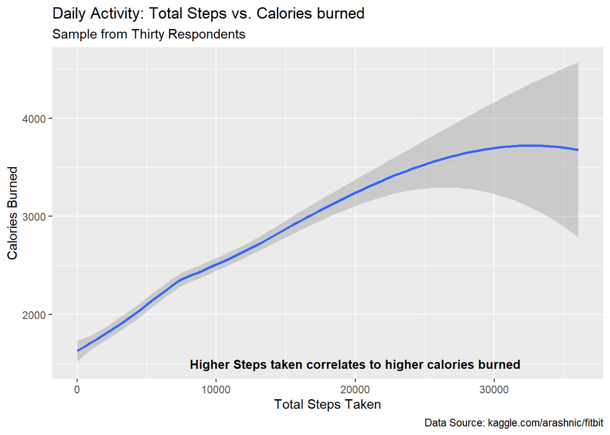

```r
ggplot(data=daily_activity) +
  geom_smooth(mapping=aes(x=TotalSteps, y=Calories)) +
  labs(title="Daily Activity: Total Steps vs. Calories burned", subtitle= "Sample from Thirty Respondents",
       caption="Data Source: kaggle.com/arashnic/fitbit", x="Total Steps Taken",y="Calories Burned")+
  annotate ("text", x=20000, y=1500, label="Higher Steps taken correlates to higher calories burned", color="black", fontface="bold", size=3.5, angle=0)
```

Unsurprisingly, those who clocked higher number of steps ended up burning more calories.
$$\\[0.005in]$$

#### **Finding out the relationship between total minutes asleep and total time spent in bed**

[figure not shown]

```r
ggplot(data=sleep_day) +
  geom_point(mapping=aes(x=TotalMinutesAsleep, y=TotalTimeInBed)) +
  labs(title="Sleeping Pattern: Total time asleep vs. Total time in bed", subtitle= "Sample from Thirty Respondents",
       caption="Data Source: kaggle.com/arashnic/fitbit", x="Total Minutes Asleep",y="Total Time in Bed")+
  annotate ("text", x=500, y=100, label="Significant number of respondents are awake in bed", color="black", fontface="bold", size=3.5, angle=0)
```

The result shows that significant number of respondents choose not to or are facing problem falling asleep.
$$\\[0.005in]$$

#### **Finding out the relationship between total time asleep and high intensity activity**

[figure not shown]

```r
ggplot(data=combined_sleep_activity) +
  geom_smooth(mapping=aes(x=TotalMinutesAsleep, y=VeryActiveDistance)) +
  labs(title="Sleeping Pattern: Total time asleep vs. Very Active Distance", subtitle= "Sample from Thirty Respondents",
       caption="Data Source: kaggle.com/arashnic/fitbit", x="Total Minutes Asleep",y="Very Active Distance")+
  annotate ("text", x=400, y=0.7, label="Most active respondents slept approx. 300 mins per day", color="black", fontface="bold", size=3.5, angle=0)
```

[figure not shown]

```r
#### **Finding out the relationship between total time asleep and BMI**
ggplot(data=combined_sleep_weight) +
  geom_smooth(mapping=aes(x=TotalMinutesAsleep, y=BMI)) +
  labs(title="Sleeping Pattern: Total time asleep vs. Weight", subtitle= "Sample from Thirty Respondents",
       caption="Data Source: kaggle.com/arashnic/fitbit", x="Total Minutes Asleep",y="BMI")+
  annotate ("text", x=400, y=20, label="Respondents who sleep more than 600 minutes per day tend to have increased BMI", color="black", fontface="bold", size=3.5, angle=0)
```

## **6. Act (Key Insights and Recommendation)**

#### **For Users who have potential sleeping issues**

- When the smart device detect that user are in bed but not asleep yet, Bellabeat can possibly push a notification to such user and provide tips to ease users into sleep if they are having insomnia.
  $$\\[0.005in]$$

#### **Smart devices to be used during sleep**

- There were 33 responses for “daily_activity” and only 24 responses for “sleep_day”. This may suggest that many respondents are not used to wear smart devices to sleep. As such, this may be an opportunity for Bellabeat to introduce an alternative smart device for users that want to track their sleeping patterns but do not feel comfortable to wear a smart watch to sleep.
  $$\\[0.005in]$$

#### **Providing of health data**

- As there were only 8 distinct responses from the weight dataset, this may suggest that either that the smart device did not proactively get users to upload their weight data or users are not comfortable with providing their weight data. Either way, this is an opportunity for Bellabeat to provide benefits to users that upload their health data (height, weight, etc). For instance, some useful tips can be provided to users who provide their health data and if users wish to find out more, they can be prompted to try Bellabeat subscription.
  $$\\[0.005in]$$